# PROPSER LOAN DATA EXPLORATION by LONG NGUYEN

### Total inquiries vs Charged off

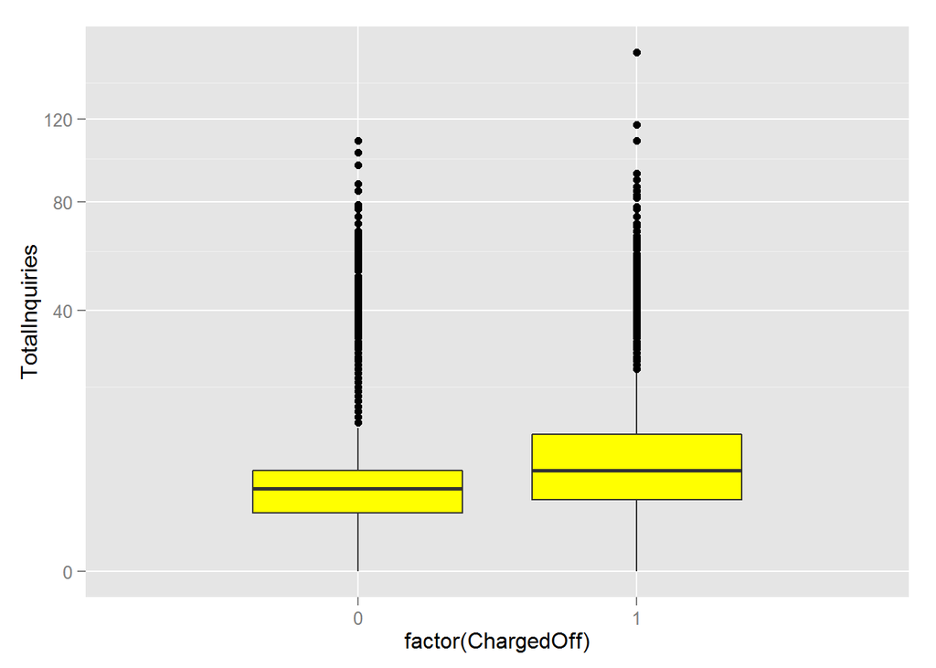

It’s shown that the median of total inquiries for non-charged-off loans is slightly smaller than that of charged-off loans. Also, the range of total inquries value for charged-off loans is higher, and the values seems to spread out more. This suggests that non-charged-off borrowers’ total inquiries value is relatively small and most borrowers have values that fall within a small range, while charged-off borrowers have values that are relatively high and values fall within a larger range, suggesting that inquiries numbers are more diverse and unique.

### APR vs Charged off

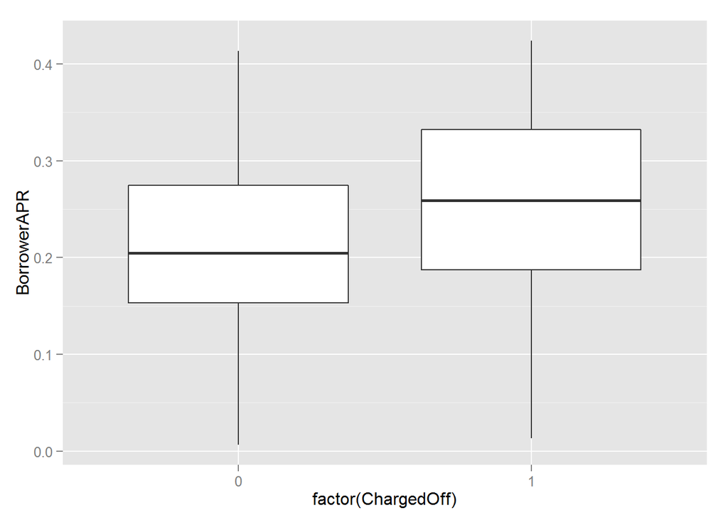

As we can see here, the distributions of APR among charged-off and non-charged-off borrwers are pretty similar. Values are evenly spread out among two groups and the ranges are similar too. However, the median APR for borrowers who did not default is lower than that of borrowers who defaulted. This suggests that APR might be a good indicator of default risk.

# Bivariate Analysis

### Talk about some of the relationships you observed in this part of the investigation. How did the feature(s) of interest vary with other features in the dataset?

Borrowers who defaulted have lower average credit score. Also, the range of credit score for charged-off borrwers is larger, which means that having score too large or too small might increase the default risk.

For total inquires, the median number of inquiries for charged-off loans is slightly higher than that of non-charged-off. This means that borrowers whom creditors tend to have more questions about have a higher chance of default. Also, the range of values iis also larger for charged-off group, which means that values are too high might suggest a higher charged-off risk.

For APR, the median APR for charged-off group is higher. Also, the inter-quantile range of charged-off group is higher, which means that generally, people who got charged off have higher APR than people who did not get charged-off

### Did you observe any interesting relationships between the other features (not the main feature(s) of interest)?

Average credit score and bank card utilization seem to have high correlation. I wonder what is the cause for this. DOes it have something to do with borrowers’ credit responsibility?

### What was the strongest relationship you found?

The strongest relationship I found was between available credit balance and monthly revolving monthly payment. The correlation is estimated to be 0.778.

# Multivariate Plots Section

Since my ultimate goal is to create a trained model that can effectively classify whether or not a loan will default, I’m interested in looking at each pairs of variable to see if default and non-default loans are linearly separable on two-dimension feature space. Since Random Forest has given me a list of what it thinks are important variables, I will start from there. I will try to combine pairs of important variables.

### Charged-off in APR vs Prosper principal outstanding

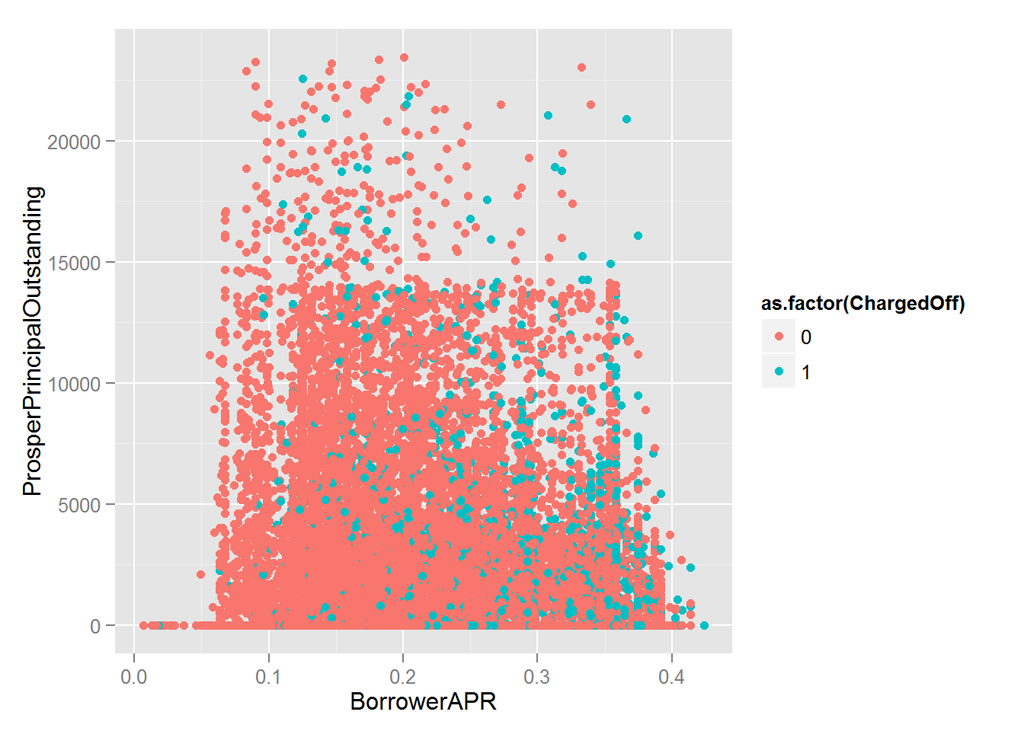

### Charged-off in APR vs Employment status

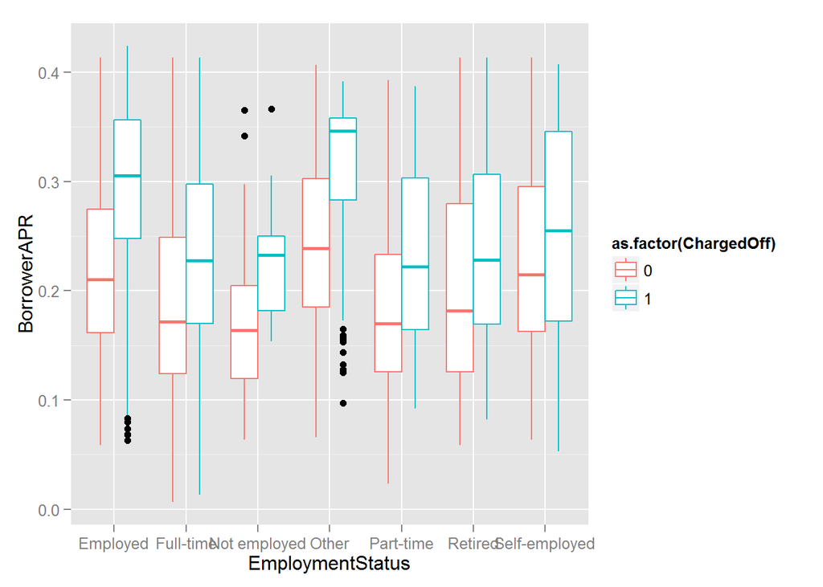

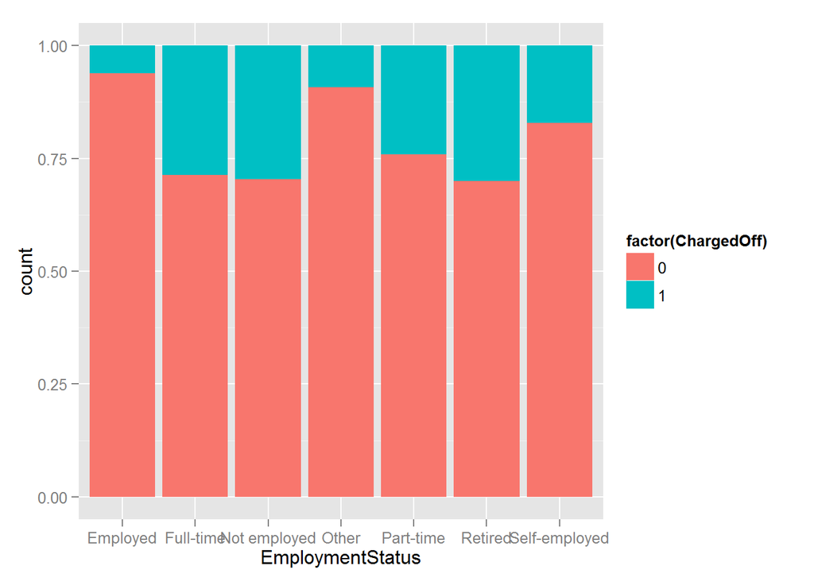

### Charged-off in APR vs Available bank card credit

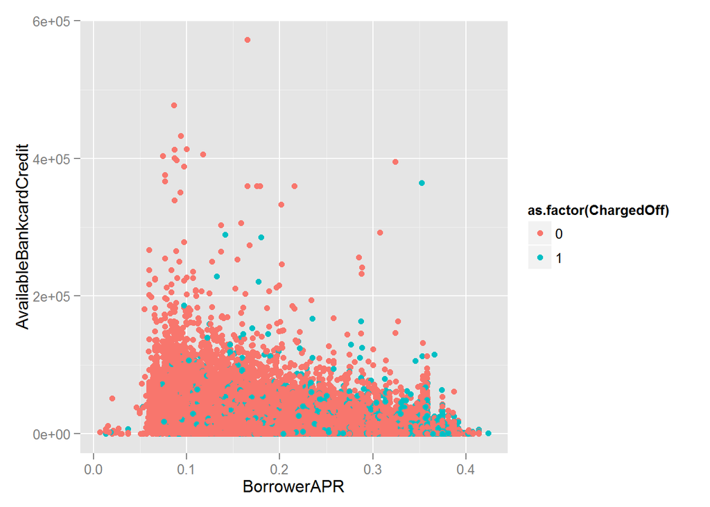

As we can see, it’s hard to separate between dafaulted loans and non-defaulted loans, which suggest that Available Bank Card Credit and APR together does not do a good job of discriminating between defaulted and non-defaulted loans.

Now I will try to pair two relatively weak variable

### Charged-off in Public record (last 10 years) vs Prosper principal outstanding

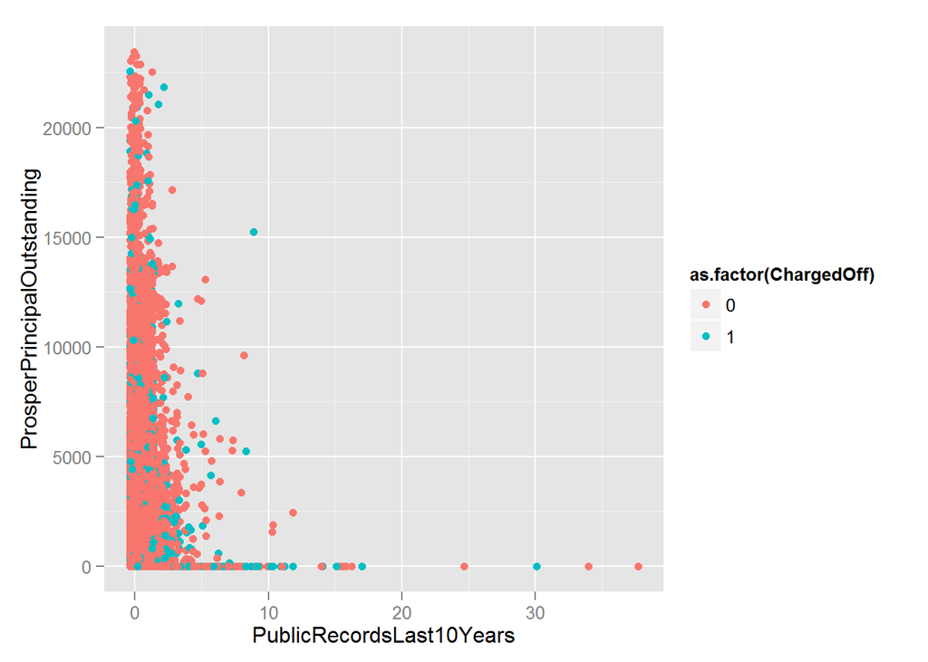

Again, we can’t separate between charged-off and non-charged-off loans in this two-dimensional feature space.

I will try to pair important variables that are highly related to each other.

### Charged-off in Average credit score vs Total inquiries

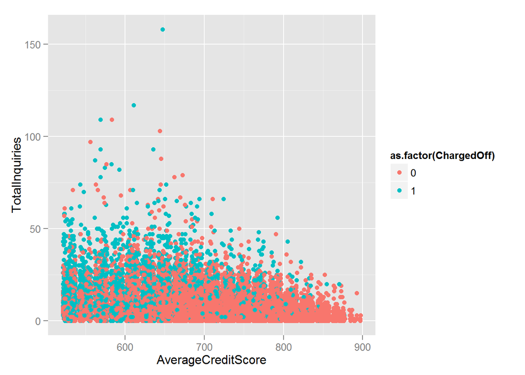

Now it seems that variables that have high predictive power and highly correlated to each other are what we are looking for. This is because variables with high predictive power will make it easier to separate two classes. Also, if two variables are highly related to each other, it wouldn’t matter which one get split first, which means the data points will be well separated. Let’s test this.

### Charged-off in Average credit score vs Employment status

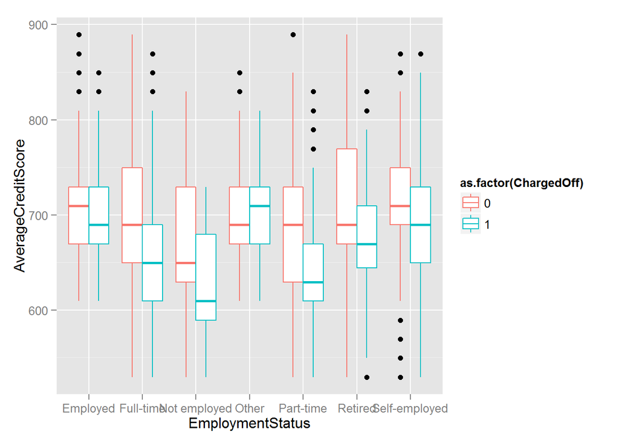

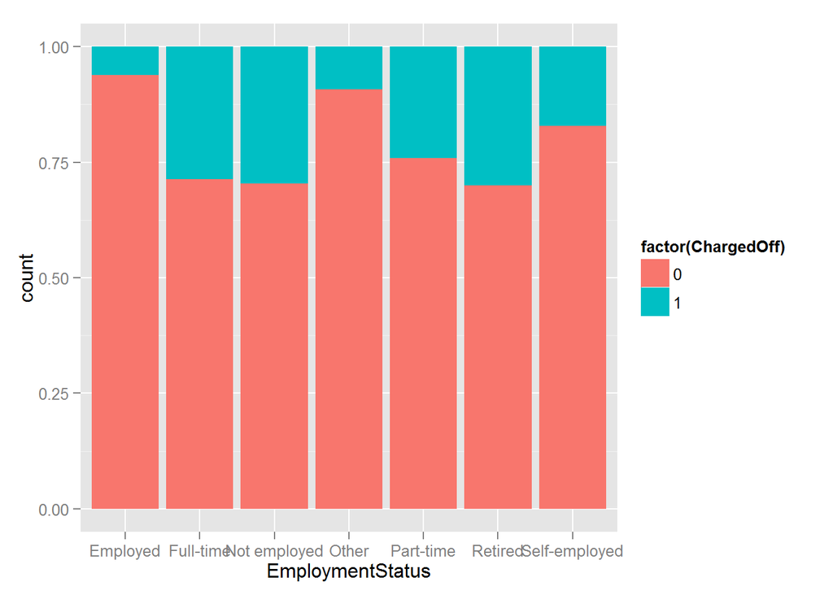

Also, if we were to split the data by Employment Status, we can see that people with “full-time”,“not-employed”, or “retired” have higher chance of getting default than people with other employment status. Combine these two insights, we can do a pretty good job of classifying which loans are likely to default

# Multivariate Analysis

### Talk about some of the relationships you observed in this part of the investigation. Were there features that strengthened each other in terms of looking at your feature(s) of interest?

There are many interesting relationships that I found. It seems that most important variables can be paird together in our model. Even though there is some multicolinearity issue, yet this doesn’t reduce the predictive power of any of important variables (their ranks are still high and we can separate the data points on their feature space). Therefore, I think these pairs of features would benefit my model. Yet weaker variables’ predictive power may be strengthen by using additional features. Therefore, a systematic approach to feature selection is needed.

### OPTIONAL: Did you create any models with your dataset? Discuss the strengths and limitations of your model.

Bayes predict

```
##
## bayes_predict          0          1
##             0 0.91806481 0.08193519
##             1 0.62829600 0.37170400
```

Forest predict

```
##
## forest_predict         0         1
##              0 0.8920531 0.1079469
##              1 0.4077079 0.5922921
```

SVM predict

```
##
## svm_predict         0         1
##           0 0.8788321 0.1211679
##           1 0.3517060 0.6482940
```

Voting predict

```
##
## pred_vote         0         1
##         0 0.8906164 0.1093836
##         1 0.4084052 0.5915948
```

# Final Plots and Summary

### Plot One

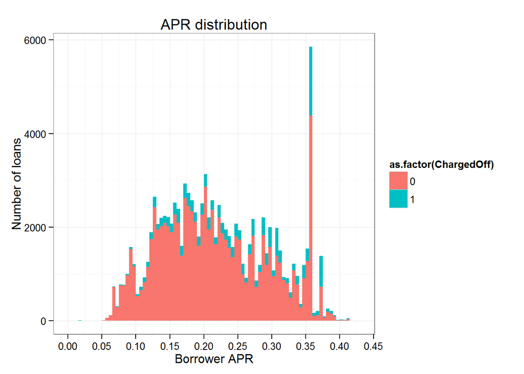

### Description One

The distribution appears to be bimodal with most loans have APR around 0.2 and 0.35, suggesting that some every risky loans are priced very high. Also, it shows that loans with higher APR have higher charged-off risk.

### Plot Two

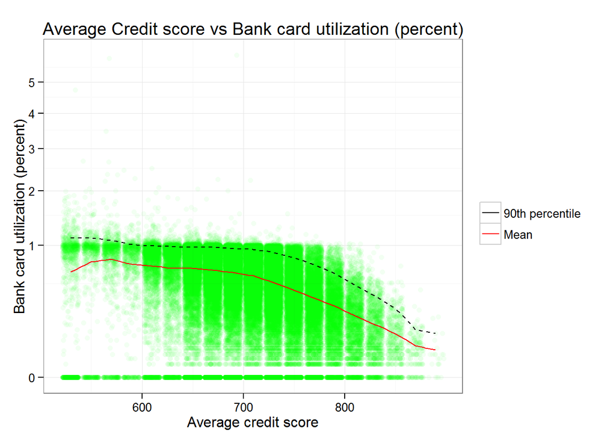